# Forecasting FinMetrics

Oskar Allerslev

2024-09-21

suppose that data follows a stationary AR(1) model on the form

$x_t = \mu + \rho x_{t-1}+\epsilon_t, \hspace{0,35cm} t\geq 1$

With $\epsilon$ iid $\mathcal{N}(0,\sigma^2), \sigma^2 > 0$.

1. Provide an expression for $E(X_{T+h} \mid \mathcal{F}_t)$ as a function of $x_T$ and the parameters of the model. Also show $x_{T+h} \mid X_{t} \overset{p}{\rightarrow} E(x_t)$ as $h \rightarrow \infty$

$$\begin{align*}
E(x_{T+h} \mid \mathcal{F}_T) &= E(\mu + \rho x_{T}+\epsilon_{T+h}
\mid \mathcal{F}_T) \\
&=\mu + \rho x_{T} + E(\epsilon_{T+h})\\
&=\mu +\rho(\mu + \rho x_{T+1}) \\
&= \dots \\
&=\mu \sum_{i=0}^{h-1}\rho^i + \rho^h x_T
\end{align*}$$

we utilize that $\rho^h x_{T}$ tends to zero as $h \rightarrow \infty$ since $\mid \rho \mid < 1$ given that data is a stationary time series.
$$\begin{align*}
E(x_{T+h} \mid \mathcal{F}_T) =\mu \sum_{i=0}^{h-1} \rho^i=
\mu\frac{1-\rho^h}{1-\rho} \overset{h \rightarrow \infty}{=}
\frac{\mu}{1-\rho} = E(x_t^*)
\end{align*}$$
for a stationary series.

2. Make a simulation and plot the points $(t, x_t \mid x_{T})$ for appropriate values for the model parameters.

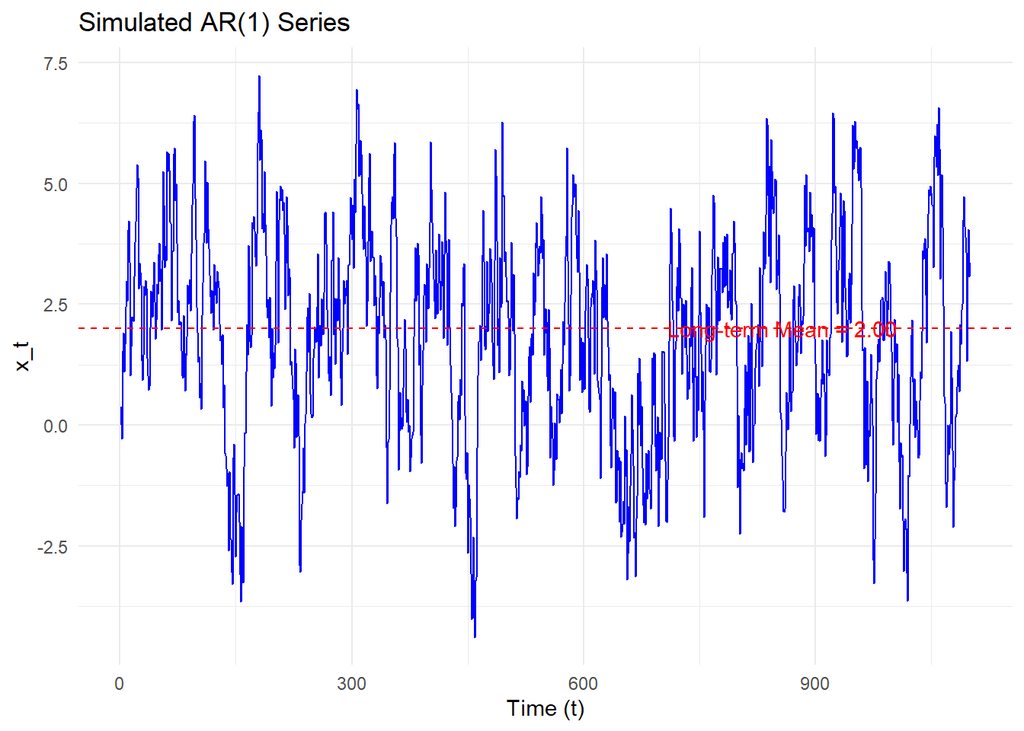

```r
library(ggplot2)

mu <- 0.2
rho <- 0.9
sigma <- 1
T <- 1000
h <- 100


x <- numeric(T+h)
x[1] <- 0

set.seed(1)
epsilon <- rnorm(T+h, mean = 0, sd = sigma)
for (t in 2:(T+h)){
  x[t] <- mu + rho *x[t-1]+epsilon[t]
}

long_term_mean <- mu/(1-rho)

data <- data.frame(Time = 1:(T+h),x = x)


ggplot(data, aes(x = Time, y = x)) +
  geom_line(color = "blue") +
  geom_hline(yintercept = long_term_mean, linetype = "dashed", color = "red") +
  labs(title = "Simulated AR(1) Series",
       x = "Time (t)", y = "x_t") +
  theme_minimal() +
  annotate("text", x = T + 5, y = long_term_mean, label = sprintf("Long-term Mean = %.2f", long_term_mean),
           color = "red", hjust = 1)
```

which is consistent with our convergence result.

3. Consider the forecast error $\epsilon_{t+h\mid T} = x_{t+h}-x_{T+h\mid T}$. Show

$$\begin{align*}
\epsilon_{T+h\mid T} \sim \mathcal{N}(0,\sigma_h^2)
\end{align*}$$
We start by finding an expression for the above

$$\begin{align*}
\epsilon_{t+h\mid T} &= x_{T+h}- x_{T+h\mid T}\\
&= \mu \sum_{i=0}^{h-1} \rho^i +\rho^h x_T +\sum_{j=0}^{h-1}\rho^j
\epsilon_{T+h-j}-\left( \mu \sum_{i=0}^{h-1} \rho^i +\rho^h x_T
\right)\\
&=\sum_{j=0}^{h-1} \rho^j \epsilon_{T+h-j}
\end{align*}$$
Which is a scaled sum of iid $\mathcal{N}(0,\sigma^2)$. Hence
$$\begin{align*}
E(\epsilon_{t+h\mid T})&=E\left( \sum_{j=0}^{n-1} \rho^{j}
\epsilon_{T+h-j} \right)=0\\
E(\epsilon_{t+h\mid T})&=E\left( \sum_{j=0}^{n-1}
\rho^{2j}\epsilon_{T+h-j}^2 \right)=\sigma^2
\sum_{j=0}^{h-1}\rho^{2j}=\sigma^2 \frac{1-\rho^{2h}}{1-\rho^2}
\end{align*}$$

hence we achieve the desired result and find an expression for the variance of the forecast error.

4. Show $\lim_{h\rightarrow \infty} \sigma_h^2 = V(x_t^*)$ and add confidence bands to the plot.

$$\begin{align*}
\sigma^2 \frac{1-\rho^{2h}}{1-\rho^2} \overset{h\rightarrow \infty}{=}
\frac{\sigma^2}{1-\rho^2}= V(x_t^*)
\end{align*}$$
We can then choose some arbitrary parameters but remember to keep $\mid \rho \mid < 1$ since that is the requirement for stationarity in the AR(1) setting.

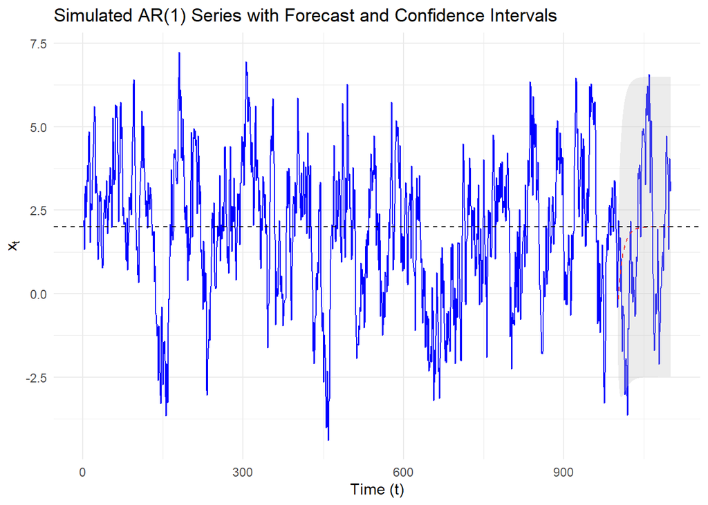

```r
library(ggplot2)

mu <- 0.2
rho <- 0.9
sigma <- 1.0
T <- 1000
h <- 100

x <- numeric(T + h)
x[1] <- mu / (1 - rho)

set.seed(1)
epsilon <- rnorm(T + h, mean = 0, sd = sigma)
for (t in 2:(T + h)) {
  x[t] <- mu + rho * x[t - 1] + epsilon[t]
}

forecast_values <- numeric(h)
lower_bound <- numeric(h)
upper_bound <- numeric(h)
z_alpha <- 1.96

for (j in 1:h) {
  forecast_values[j] <- mu * (1 - rho^j) / (1 - rho) + rho^j * x[T]
  sigma_h <- sigma * sqrt((1 - rho^(2 * j)) / (1 - rho^2))
  lower_bound[j] <- forecast_values[j] - z_alpha * sigma_h
  upper_bound[j] <- forecast_values[j] + z_alpha * sigma_h
}

forecast_df <- data.frame(
  Time = (T + 1):(T + h),
  Forecast = forecast_values,
  Lower = lower_bound,
  Upper = upper_bound
)

data <- data.frame(Time = 1:(T + h), x = x)

ggplot(data, aes(x = Time, y = x)) +
  geom_line(color = "blue") +
  geom_line(data = forecast_df, aes(x = Time, y = Forecast), color = "red", linetype = "dashed") +
  geom_ribbon(data = forecast_df, aes(x = Time, ymin = Lower, ymax = Upper),
              fill = "gray", alpha = 0.3, inherit.aes = FALSE) +
  geom_hline(yintercept = mu / (1 - rho), linetype = "dashed", color = "black") +
  labs(title = "Simulated AR(1) Series with Forecast and Confidence Intervals",
       x = "Time (t)", y = expression(x[t])) +
  theme_minimal()
```

5. Try to evaluate how one could use this in practice